# Factors Lab Key

## BONUS

7. Take your code from #7 and assign it to the variable “vacc_dat”.
- Filter out the “United States” from `State/Territory/Federal Entity`. Make sure to reassign this to “vacc_dat”
- Create a ggplot boxplot (`geom_boxplot()`) where (1) the x-axis is `Total Doses Delivered` and (2) the y-axis is `Percent of fully vaccinated people with booster doses`.
- You change the `labs()` layer so that the x-axis is “Total Doses Delivered: Greater than 10,000,000”

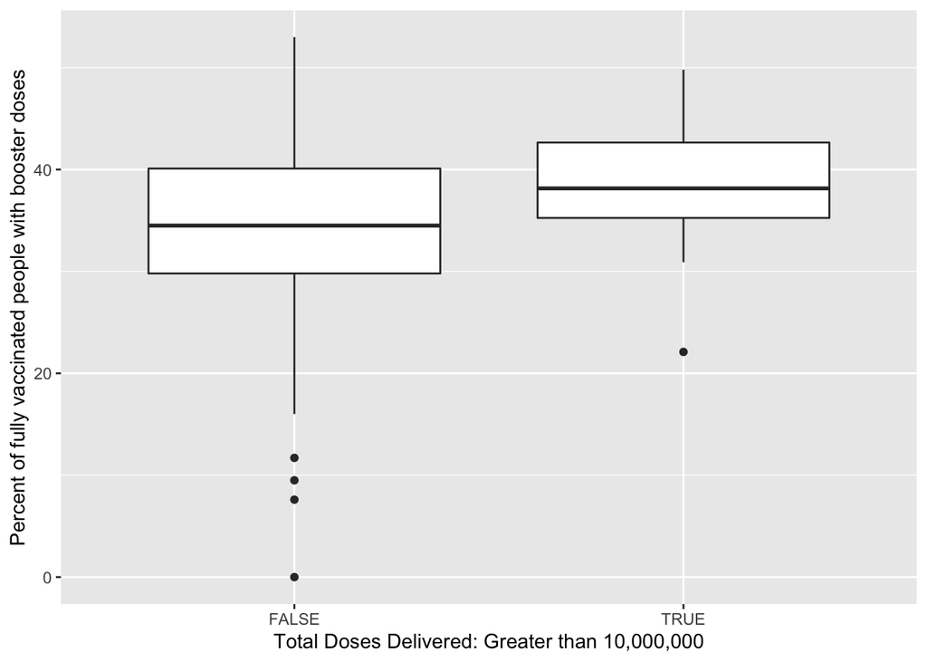

```r
vacc_dat <-
  vacc %>%
  mutate(across(.cols = starts_with("Total"),
                .fns = function(x) x > 10000000)) %>%
  filter(`State/Territory/Federal Entity` != "United States")

ggplot(vacc_dat) +
  geom_boxplot(aes(x = `Total Doses Delivered`,
                   y = `Percent of fully vaccinated people with booster doses`)) +
  labs(x = "Total Doses Delivered: Greater than 10,000,000")
```